# Homework 4

Shivam Bajaj

February 6, 2023

1. There is a dataset of clinical variables and self-reported fall history from people with Parkinson’s disease available at [https://jlucasmckay.bmi.emory.edu/global/mckay_2021/S1.csv]. Identify the sample mean and sample standard deviation of the `Age` variable. Exclude any cases under 35 years old. **1 point**

```r
data <- read.csv("https://jlucasmckay.bmi.emory.edu/global/mckay_2021/S1.csv")
data <- data[data$Age >= 35,]

m <- mean(data$Age)
s <- sd(data$Age)
l <- length(data$Age)
print(m)
```

```
## [1] 67.36935
```

```r
print(s)
```

```
## [1] 7.418488
```

2. Calculate the likelihood of the estimates for the mean and standard deviation you have obtained given the sample. (Assume a normal distribution.) as you sweep the estimate of average age through ±2 years. Specifically, create a function `Lik(a)` that returns the likelihood of the data given an estimate of the population mean age `a` **(1/2 point)** and plot the likelihood as a function of `a` as you sweep it over ±2 years. **(1/2 point)**

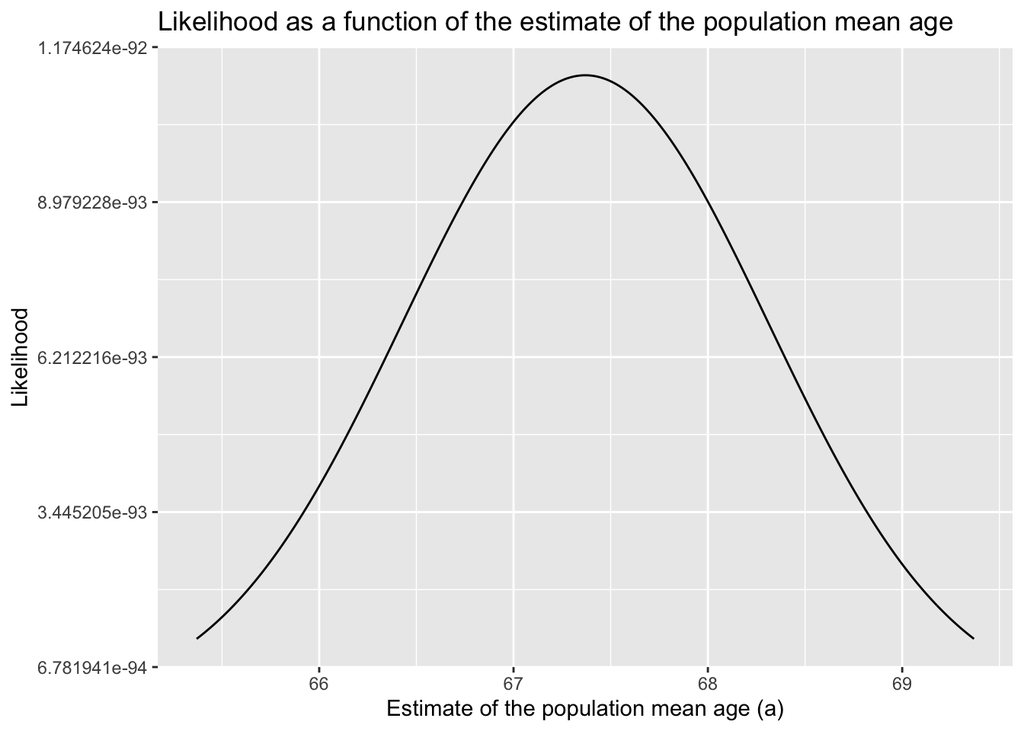

```r
# Define the likelihood function

Age <- data$Age
Lik <- function(a) {

  likelihood <- prod(dnorm(Age, mean = a, sd = s))
  return(likelihood)
}


library(ggplot2)

a_range <- seq(from = m - 2, to = m + 2, by = 0.01)
likelihood_values <- sapply(a_range, Lik)


ggplot(data.frame(a = a_range, likelihood = likelihood_values), aes(x = a, y = likelihood)) +
  geom_line() +
  ggtitle("Likelihood as a function of the estimate of the population mean age") +
  xlab("Estimate of the population mean age (a)") +
  ylab("Likelihood")
```

3. Now plot the *log* likelihood as you sweep the estimate of average age through ±2 years. **(1 point)** *(Note that you have to use a sum, not a product, here.)*

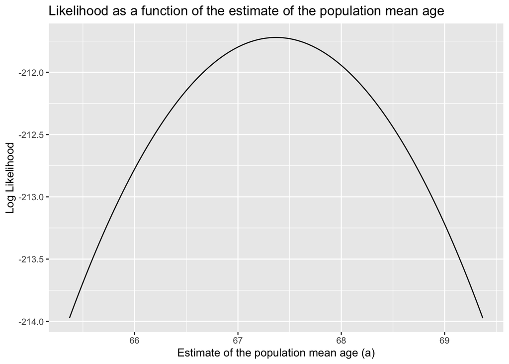

```r
Age <- data$Age
logLik <- function(a) {

  likelihood <- sum(dnorm(Age, mean = a, sd = s, log = TRUE))
  return(likelihood)
}


library(ggplot2)

a_range <- seq(from = m - 2, to = m + 2, by = 0.01)
log_likelihood_values <- sapply(a_range, logLik)


ggplot(data.frame(a = a_range, log_likelihood = log_likelihood_values), aes(x = a, y = log_likelihood)) +
  geom_line() +
  ggtitle("Likelihood as a function of the estimate of the population mean age") +
  xlab("Estimate of the population mean age (a)") +
  ylab("Log Likelihood")
```

4. Using the answers for the last two questions, use a grid-based approach to find the maximum likelihood estimator for `a`. **(1/2 point)** Do the same for the maximum log-likelihood estimator. **(1/2 point)** Do they differ?

```r
grid <- seq(from = min(Age), to = max(Age), by = 1)

#assigning a empty vector of length grid
lik_values <- numeric(length(grid))
loglik_values <- numeric(length(grid))

#calculating log likelihood and likelihood for all values in grid
for (i in 1:length(grid)) {
  lik_values[i] <- Lik(grid[i])
  loglik_values[i] <- logLik(grid[i])
}

#calculating max likelihood and log likelihood
max_index_likelihood <- which.max(lik_values)
max_index_loglikelihood <- which.max(loglik_values)

a_hat_likelihood <- grid[max_index_likelihood]
a_hat_loglikelihood <- grid[max_index_loglikelihood]


cat("liklihood age",a_hat_likelihood)
## liklihood age 67
cat("\nlog liklihood age", a_hat_loglikelihood)
```

```
##
## log liklihood age 67
```

```r
#we see that they do not differ.
```

5. One of the things we noted was that using the sample standard deviation to estimate the population standard deviation can bias the estimate. Therefore, we often see `N-1` normalization in the standard deviation equation instead of `N`. Calculate and compare the likelihood of the data under the biased and unbiased estimators for the standard deviation. Which estimate for the standard deviation is larger? Which estimate is more likely? **(1 point)**

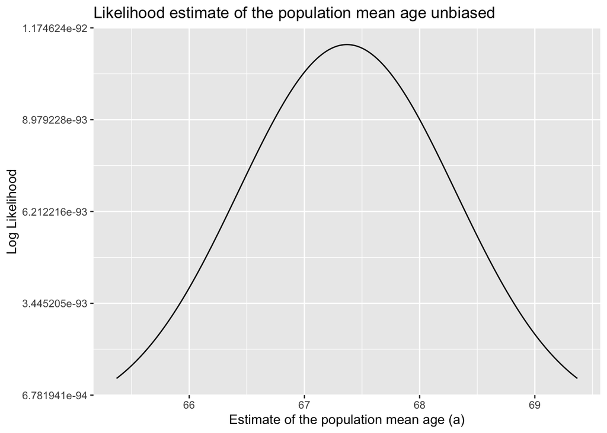

```r
bias_sd <- sqrt(sum((data$Age - mean(data$Age))^2) / length(data$Age))
unbias_sd <- sqrt(sum((data$Age - mean(data$Age))^2) / (length(data$Age) - 1))


Lik_biased <- function(a) {
  likelihood <- prod(dnorm(Age, mean = a, sd = bias_sd))#sd(N)
  return(likelihood)
}


Lik_unbiased <- function(a) {
  likelihood <- prod(dnorm(Age, mean = a, sd = unbias_sd))#sd(N-1)
  return(likelihood)
}


a_range <- seq(from = m - 2, to = m + 2, by = 0.01)
likelihood_values <- sapply(a_range, Lik_unbiased)


ggplot(data.frame(a = a_range, likelihood = likelihood_values), aes(x = a, y = likelihood)) +
  geom_line() +
  ggtitle("Likelihood estimate of the population mean age unbiased") +
  xlab("Estimate of the population mean age (a)") +
  ylab("Log Likelihood")
```

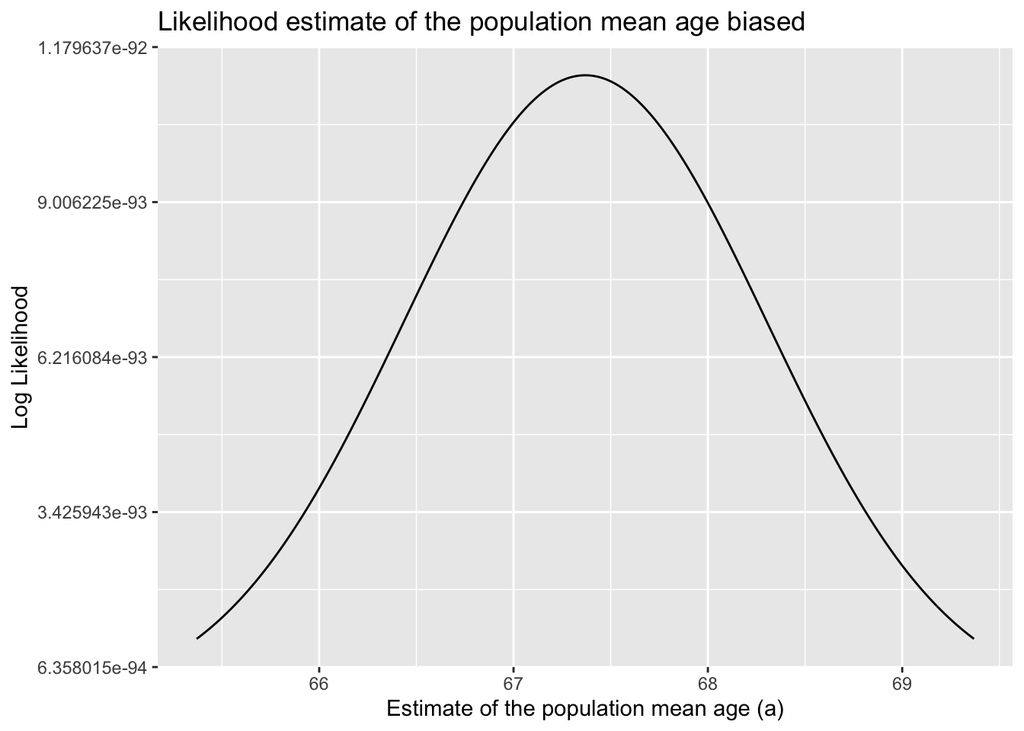

```r
a_range <- seq(from = m - 2, to = m + 2, by = 0.01)
likelihood_values <- sapply(a_range, Lik_biased)


ggplot(data.frame(a = a_range, likelihood = likelihood_values), aes(x = a, y = likelihood)) +
  geom_line() +
  ggtitle("Likelihood estimate of the population mean age biased") +
  xlab("Estimate of the population mean age (a)") +
  ylab("Log Likelihood")
```